# Variáveis aleatórias

ProbEst

fnaufel

19/10/2020 (modificado em 17/09/2021)

# 1 Variáveis aleatórias

- Uma variável aleatória é uma maneira de associar a cada resultado do espaço amostral um *número real*.
- Dependendo do conjunto de números, a variável aleatória pode ser *discreta* ou *contínua*.
- Falamos sobre a *probabilidade* de uma variável aleatória assumir um valor (ou uma faixa de valores).

# 2 Exemplos

## 2.1 Lançar dois dados

- Definimos $X = \text{soma dos resultados dos dois dados}$.
- Esta é uma variável aleatória *discreta*, com $11$ valores possíveis.
- Tabela completa = distribuição de probabilidade:

```r
dados_distr <- expand.grid(1:6, 1:6) %>%
  mutate(
    x = Var1 + Var2
  ) %>%
  group_by(x) %>%
  summarize(
    'P(X = x)' = paste(n(), 36, sep = '/'),
    num = n() / 36,
    .groups = 'drop'
  )

dados_distr %>%
  kbl(
    align = 'r',
    format.args = list(big.mark = '.')
  ) %>%
  kable_paper(
    c('striped', 'hover'),
    full_width = FALSE
  )
```

| x | P(X = x) | num |
| --- | --- | --- |
| 2 | 1/36 | 0,0277778 |
| 3 | 2/36 | 0,0555556 |
| 4 | 3/36 | 0,0833333 |
| 5 | 4/36 | 0,1111111 |
| 6 | 5/36 | 0,1388889 |
| 7 | 6/36 | 0,1666667 |
| 8 | 5/36 | 0,1388889 |
| 9 | 4/36 | 0,1111111 |
| 10 | 3/36 | 0,0833333 |
| 11 | 2/36 | 0,0555556 |
| 12 | 1/36 | 0,0277778 |

- Graficamente:

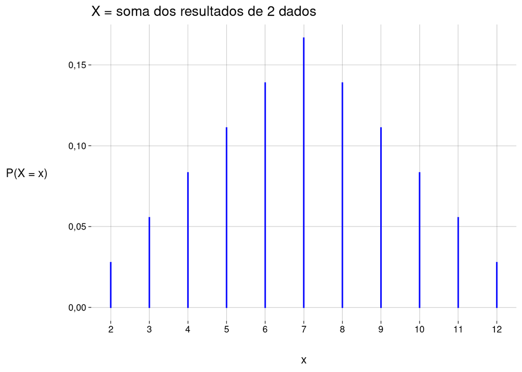

```r
dados_distr %>%
  ggplot(aes(x = x, y = num)) +
    geom_col(width = .01, color = 'blue') +
    scale_x_continuous(breaks = 2:12) +
    labs(
      title = 'X = soma dos resultados de 2 dados',
      y = 'P(X = x)'
    )
```

- Qual a probabilidade de conseguir 10 ou mais?

```r
dados_distr %>%
  filter(x >= 10) %>%
  summarize(p = sum(num))
```

| p |
| --- |
| 0,1666667 |

- Qual a probabilidade de conseguir entre 6 e 8, inclusive?

```r
dados_distr %>%
  filter(x >= 6 & x <= 8) %>%
  summarize(p = sum(num))
```

| p |
| --- |
| 0,4444444 |

## 2.2 Altura de um homem adulto

- Definimos $X = \text{estatura em metros de um homem brasileiro adulto, escolhido ao acaso}$.
- Esta é uma variável aleatória *contínua*, com um número *infinito não-enumerável* de valores.
- Segundo o [Levantamento do Perfil Antropométrico da População Brasileira Usuária do Transporte Aéreo Nacional](https://www2.anac.gov.br/arquivos/pdf/Relatorio_Final_Projeto_Conhecer.pdf), em 2009, a estatura média do homem brasileiro adulto era de 1,73m, com desvio padrão de 0,07m.
- Vamos simular uma amostra de muitos homens desta população:

```r
media <- 1.73
desvio <- 0.07
homens <- tibble(
  altura = rnorm(1e5, mean = media, sd = desvio)
)
```

- Gráfico com as percentagens:

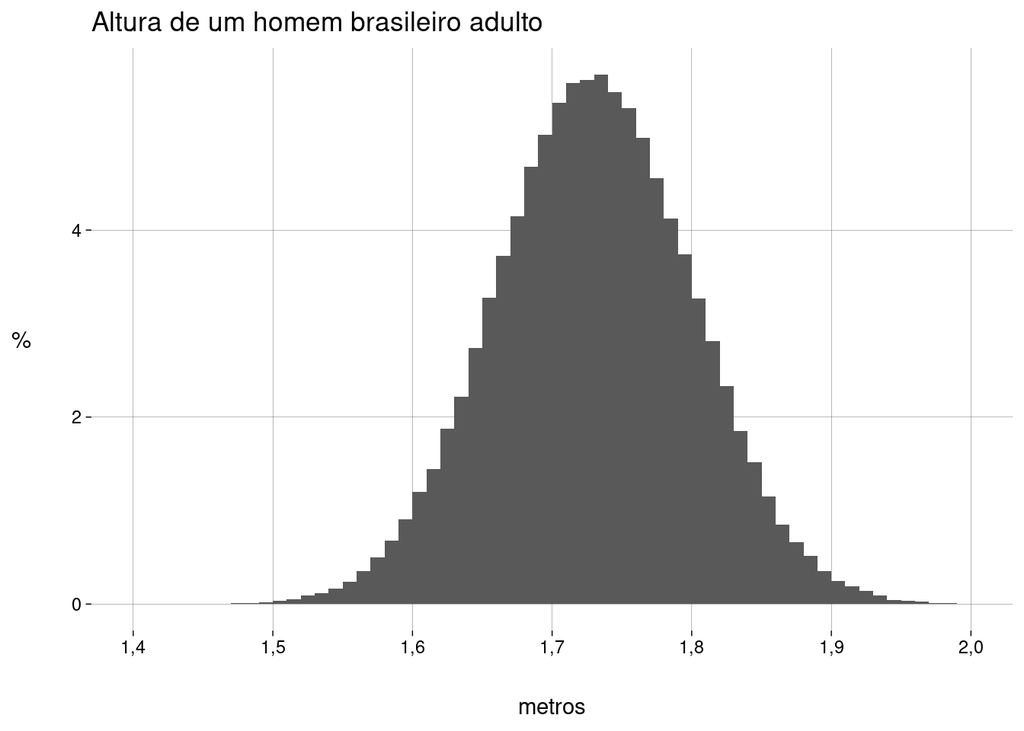

```r
homens_plot <- homens %>%
  ggplot(aes(x = altura)) +
    geom_histogram(
      aes(y = after_stat(density)),
      breaks = seq(1.4, 2, 0.01)
    ) +
    scale_x_continuous(breaks = seq(1.4, 2.0, .1)) +
    labs(
      title = 'Altura de um homem brasileiro adulto',
      x = 'metros',
      y = '%'
    )

homens_plot
```

- Com a distribuição normal:

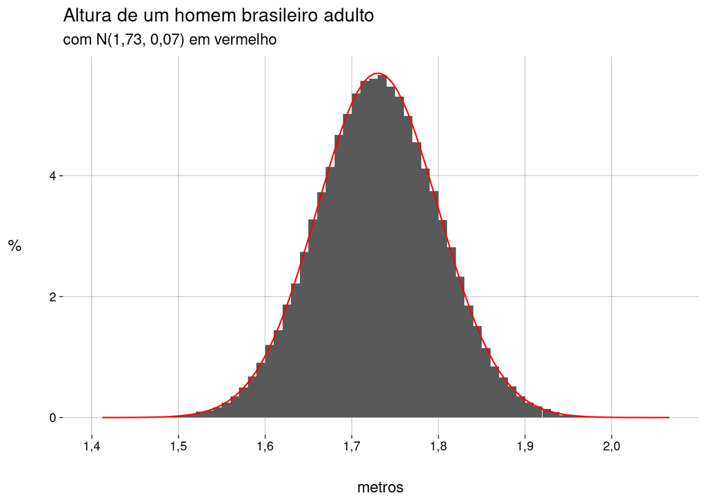

```r
homens_normal <- homens_plot +
  stat_function(
    fun = dnorm,
    args = list(
      'mean' = media,
      'sd' = desvio
    ),
    geom = 'line',
    color = 'red'
  ) +
  labs(
    subtitle = paste0('com N(', media, ', ', desvio,') em vermelho')
  )

homens_normal
```

- A curva vermelha no gráfico é a *função de densidade de probabilidade* da distribuição normal, dada por
  $$\text{fdp}(x) = {\frac {1}{\sigma {\sqrt {2\pi }}}}e^{-{\frac {1}{2}}\left({\frac {x-\mu }{\sigma }}\right)^{2}}$$

Em uma distribuição contínua, *não faz sentido* perguntar o valor de $P(X = x)$. Como $X$ pode assumir uma quantidade infinita não-enumerável de valores, esta probabilidade é igual a zero!

Com uma distribuição contínua, vamos sempre perguntar sobre *faixas de valores*.

- Qual a probabilidade de um homem ter mais de 1,80m?
  - Na amostra:

    ```r
    mean(homens$altura > 1.80)
    ```

    ```
    ## [1] 0,16105
    ```

  - Na distribuição teórica:

    ```r
    pnorm(1.80, mean = media, sd = desvio, lower.tail = FALSE)
    ```

    ```
    ## [1] 0,1586553
    ```

  - Gráfico:

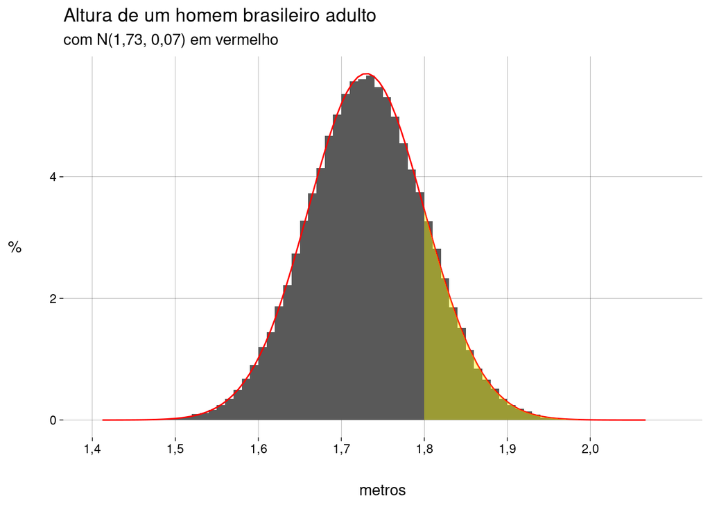

    ```r
    homens_normal +
      stat_function(
        fun = dnorm,
        args = list(
          'mean' = media,
          'sd' = desvio
        ),
        geom = 'area',
        fill = 'yellow',
        alpha = .4,
        xlim = c(1.8, 2.1)
      )
    ```

- Qual a probabilidade de um homem ter entre 1,60m e 1,70m?
  - Na amostra:

    ```r
    mean(homens$altura > 1.60 & homens$altura < 1.70)
    ```

    ```
    ## [1] 0,30316
    ```

  - Na distribuição teórica:

    ```r
    pnorm(1.70, mean = media, sd = desvio) -
    pnorm(1.60, mean = media, sd = desvio)
    ```

    ```
    ## [1] 0,3024722
    ```

  - Gráfico

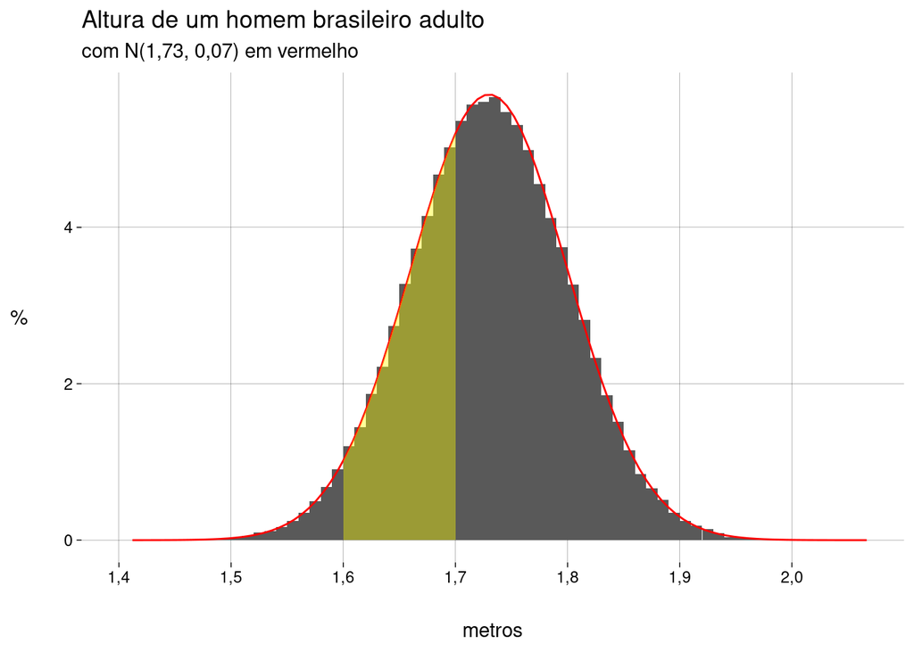

    ```r
    homens_normal +
      stat_function(
        fun = dnorm,
        args = list(
          'mean' = media,
          'sd' = desvio
        ),
        geom = 'area',
        fill = 'yellow',
        alpha = .4,
        xlim = c(1.6, 1.7)
      )
    ```

# 3 Valor esperado

- O *valor esperado* (ou *esperança matemática*) de uma variável aleatória é a média ponderada dos valores possíveis da variável, considerando as probabilidades (ou, no caso contínuo, a *densidade* de probabilidade) como pesos.
- Caso discreto:
  $$\mu = E(X) = \sum_i x_i \cdot P(X = x_i)$$
- Caso contínuo:
  $$\mu = E(X) = \int_{-\infty}^{+\infty} x \cdot \text{fdp}(x) dx$$

## 3.1 Lançar dois dados

```r
dados_distr %>%
  summarize(E = sum(x * num))
```

| E |
| --- |
| 7 |

## 3.2 Lançar um dado

```r
lado <- 1:6
p <- 1/6
sum(lado * p)
```

```
## [1] 3,5
```

## 3.3 Altura de um homem adulto

- Estimando pela média da amostra:

```r
mean(homens$altura)
```

```
## [1] 1,730075
```

- Se $X$ é normalmente distribuída, i.e., $X \sim \mathcal{N}(\mu, \sigma)$, então $E(X) = \mu$, que é o valor de
  $$\int_{-\infty}^{+\infty} x \cdot {\frac {1}{\sigma {\sqrt {2\pi }}}}e^{-{\frac {1}{2}}\left({\frac {x-\mu }{\sigma }}\right)^{2}} dx$$

## 3.4 Propriedades do valor esperado

- O valor esperado de uma constante é ela mesma:
  $$E(c) = c$$
- Somar uma constante a $X$ altera $E(X)$ pelo valor da constante:
  $$E(X \pm c) = E(X) \pm c$$
- Multiplicar $X$ por uma constante multiplica $E(X)$ pelo valor da constante:
  $$E(c \cdot X) = c \cdot E(X)$$
- O valor esperado da soma (resp. diferença) de duas variáveis aleatórias é a soma (resp. diferença) dos valores esperados:
  $$E(X \pm Y) = E(X) \pm E(Y)$$
- O valor esperado de uma função $f(X)$ de uma variável aleatória $X$ é
  - Caso discreto:
    $$E(f(X)) = \sum_i f(x_i) \cdot P(X = x_i)$$
  - Caso contínuo:
    $$E(f(X)) = \int_{-\infty}^{+\infty} f(x) \cdot \text{fdp}(x) dx$$

# 4 Variância

- A variância de uma variável aleatória $X$ é a média ponderada dos desvios quadrados, com as probabilidades como peso.
  - Caso discreto:
    $$\sigma^2(X) = \sum_i (x_i - \mu)^2 \cdot P(X = x_i)$$
  - Caso contínuo:
    $$\sigma^2(X) = \int_{-\infty}^{+\infty} (x - \mu)^2 \cdot \text{fdp}(x) dx$$
- Em qualquer caso,
  $$\begin{align*}
  \sigma^2(X) &= E[(X - \mu)^2]\\
  &= E(X^2) - [E(X)]^2
  \end{align*}$$
  Faça as contas, partindo de $E[(X - \mu)^2]$ e usando as propriedades do valor esperado para chegar a $E(X^2) - [E(X)]^2$.

## 4.1 Lançar dois dados

```r
dados_distr %>%
  summarize(s2 = sum((x - 7)^2 * num))
```

| s2 |
| --- |
| 5,833333 |

## 4.2 Lançar um dado

```r
lado <- 1:6
p <- 1/6
sum((lado - 3.5)^2 * p)
```

```
## [1] 2,916667
```

## 4.3 Altura de um homem adulto

- Estimando pela variância da amostra:

```r
N <- length(homens$altura)
var(homens$altura) * (N - 1) / N
```

```
## [1] 0,004935524
```

- Se $X$ é normalmente distribuída, i.e., $X \sim \mathcal{N}(\mu, \sigma)$, então $\sigma^2(X) = \sigma^2$. De acordo com o estudo, $\sigma^2 = 0.07^2 = 0{,}00$.

## 4.4 Propriedades da variância

- A variância de uma constante é zero:
  $$\sigma^2(c) = 0$$
- Somar uma constante a $X$ não altera a variância:
  $$\sigma^2(X \pm c) = \sigma^2(X)$$
- Multiplicar $X$ por uma constante multiplica a variância pelo quadrado da constante:
  $$\sigma^2(c \cdot X) = c^2 \cdot \sigma^2(X)$$
- A variância da soma ou diferença de duas variáveis aleatórias é a soma das variâncias:
  $$\sigma^2(X \pm Y) = \sigma^2(X) + \sigma^2(Y)$$

### Quê?

Variância significa incerteza.

Considere o seguinte exemplo para entender por que $\sigma^2(X - Y) = \sigma^2(X) + \sigma^2(Y)$:

- Você compra uma caixa de 500g de cereal no mercado. Como o peso não é exato, considere que $X$ é a variável aleatória que representa o peso do cereal na caixa, com $\mu_X = 500g$ e uma variância qualquer $\sigma^2_X$ (que corresponde à incerteza do processo de embalagem do cereal na fábrica).
- Você decide comer 100g de cereal, despejando 1/5 do conteúdo na caixa em uma caneca. Como sua capacidade de medir 100g não é exata, considere que $Y$ é a variável aleatória que representa o peso do cereal na caneca, com $\mu_Y = 100\text{g}$ e uma variância qualquer $\sigma^2_Y$ (que corresponde à incerteza do seu processo de pesar 100g).
- Considere a variável aleatória $Z = X - Y$, que representa a quantidade de cereal que sobrou na caixa.
  - Certamente a média $\mu_Z = \mu_X - \mu_Y = 400\text{g}$.
  - E a variância $\sigma^2_Z$? O fato de $Z$ ser o resultado da subtração de duas variáveis aleatórias diminui a incerteza? Ou a composição de incertezas (ainda que em uma subtração de medidas incertas) aumenta a incerteza?

# 5 Mais exemplos

## 5.1 Seguradora

- Você tem uma seguradora, com 1000 segurados, cada um deles pagando 50 dinheiros por ano.
- Por ano, 1 dos 1000 segurados morre. Neste caso, sua seguradora deve pagar 10.000 dinheiros.
- Por ano, 2 dos 1000 segurados ficam inválidos. Neste caso, sua seguradora deve pagar 5.000 dinheiros.
- Quanto sua seguradora espera ter de lucro (ou prejuízo) por segurado?
  - Chamando de $X$ a variável aleatória que representa o dinheiro pago pela seguradora por apólice, temos
    $$\begin{align*}
    P(X = 10.000) &= 1/1000\\
    P(X = 5.000) &= 2/1000\\
    P(X = 0) &= 997/1000
    \end{align*}$$
  - Daí,
    $$\begin{align*}
    E(X) &= 10000 \cdot \frac{1}{1000} \;+\; 5000 \cdot \frac{2}{1000} \;+\; 0 \cdot \frac{997}{1000} \\
    &= 20
    \end{align*}$$
  - Como cada segurado paga 50 dinheiros, sua seguradora lucra, em média, 30 dinheiros por apólice.
- E o desvio padrão?
  - Calculando a variância antes:
    $$\begin{align*}
    \sigma^2(X) &= (10000 - 20)^2 \cdot \frac{1}{1000} \;+\; (5000 -20)^2 \cdot \frac{2}{1000} \;+\; (0 - 20)^2 \cdot \frac{997}{1000} \\
    &= 9980^2 \cdot \frac{1}{1000} \;+\; 4980^2 \cdot \frac{2}{1000} \;+\; (- 20)^2 \cdot \frac{997}{1000} \\
    &= 149600
    \end{align*}$$
  - O desvio padrão é a raiz quadrada de $\sigma^2$:
    $$\sigma = 386,78$$

## 5.2 Gerador de números aleatórios

- Você programa um gerador de números aleatórios $x \in [1, 3] \subset \mathbb{R}$.
- Considere $X$ a variável aleatória que representa os números gerados.
- $X$ é uma variável aleatória contínua, com fdp
  $$f(x) =
  \begin{cases}
  \frac{1}{2} & \text{se } x \in [1, 3] \\
  0 & \text{se } x \not\in [1, 3]
  \end{cases}$$
  cujo gráfico é

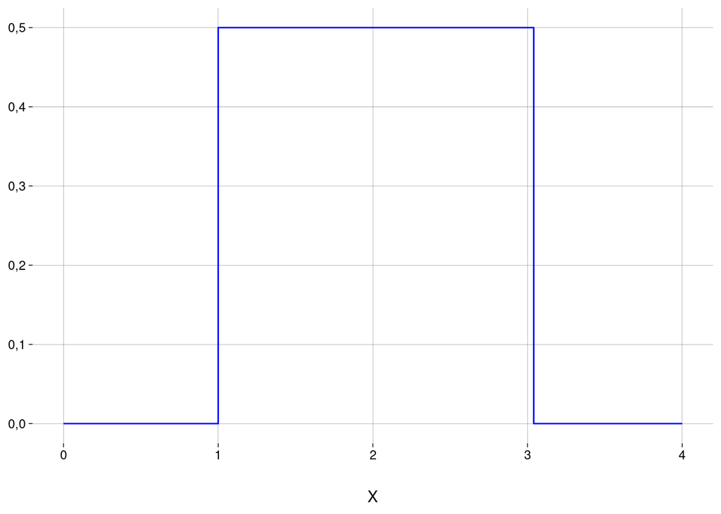

  ```r
  ggplot() +
    stat_function(
      fun = dunif,
      args = c(1, 3),
      xlim = c(0, 4),
      geom = 'step',
      color = 'blue',
    ) +
    labs(
      y = NULL,
      x = 'X'
    )
  ```

- Isto significa que a *densidade* de probabilidade está distribuída uniformemente no intervalo $[1, 3]$.
- Vamos calcular $E(X)$:
  $$\begin{align*}
  E(X)
  &= \int_{-\infty}^{+ \infty} x \cdot f(x) dx \\
  &= \int_{1}^{3} x \cdot \frac{1}{2} dx \\
  &= \frac12 \cdot \left.\frac{x^2}{2} \right|_1^3 \\
  &= 2
  \end{align*}$$
- Ou seja, a média dos números gerados, depois de muitas execuções, vai ser 2.
- Vamos calcular $\sigma^2(X)$:
  $$\begin{align*}
  \sigma^2(X)
  &= \int_{-\infty}^{+ \infty} (x - 2)^2 \cdot f(x) dx \\
  &= \int_{1}^{3} (x-2)^2 \cdot \frac{1}{2} dx \\
  &= \frac13
  \end{align*}$$
- Isto vai dar um desvio padrão $\sigma = \sqrt{\sigma^2} = \frac{\sqrt{3}}{3} \approx 0{,}58$.
- Mas R tem este gerador! Vamos gerar muitos valores e calcular a média e o desvio padrão:

```r
valores <- runif(n = 1e6, min = 1, max = 3)
mean(valores)
```

```
## [1] 2,000899
```

```r
sd(valores)
```

```
## [1] 0,5773504
```

- Como exercício, verifique que, para qualquer variável aleatória contínua $X$ distribuída uniformemente entre $a$ e $b$, i.e., com fdp
  $$f(x) =
  \begin{cases}
  \frac{1}{b - a} & \text{se } x \in [a, b] \\
  0 & \text{se } x \not\in [a, b]
  \end{cases}$$
  ocorre que
  - $E(X) = \frac{a+b}{2}$
  - $\sigma^2(X) = \frac{(a - b)^2}{12}$